# In class R Practice Sampling and Simulating Probability

March 13, 2025

Note: link to [special vectors and sampling](https://mphitchman.com/math340/sampling-in-R.html) tutorial.

## Part I: Special vectors

**1.** Define a vector `a` to be the set of integers: 1, 2, 3, $\ldots$, 10000.

**2.** Define a vector `b` to be the set of integers: 5, 10, 15, $\ldots$, 10000.

**3.** Define a vector `c` to be the set of real numbers: 0, 0.1, 0.2, 0.3, $\ldots$, 2.0.

**4.** Define a vector `class` to be the students in this class. Here, I’ll do it:

```r
class <- c("Sasha","Aidan","Annika","Santi","Eli","Jadyn","Shawn","Carter",
           "Ryder","Nick","Lisa","Alexis","Chase","Emerson","Miki")
```

## Part II: Sampling

**5.** Use the `sample()` command to define a vector `rolls` that records 10000 rolls of a fair 20 sided die. Then make a quick barplot of your data, using `barplot(table(rolls))` to see whether the die appears to be fair. That is, is the sample fairly uniform (meaning each number comes up about the same number of times)?

**6.** Load the tidyverse into your session. Then use the `sample()` command to choose a random sample of 10 distinct names from the starwars data. Is Yoda in your sample?

**7.** Use the `sample()` command to randomly pick 4 students in `class` to be in a lab group.

**8.** Use the `sample()` command to record in the vector `skee` a simulation of 1000 shots of skee ball, assuming the following probability distribution for each shot:
$$\begin{array}{c|c|c|c|c|c|c}
x & 0 & 10 & 20 & 30 & 40 & 50\\ \hline
p(x) & .1 & .2 & .1 & .1 & .4 & .1
\end{array}$$
Then make a barplot of the results. Does it reflect the probability distribution?

**9.** Use `rnorm()` to define a vector `AVG` to be a random sample of size 500 from a normal distribution with mean $\mu = 0.275$ and standard deviation $\sigma = 0.009$. Then make a quick histogram of your data, using `hist(AVG)`. Is most of your distribution within 3$\sigma$ of $\mu$?

**10.** Use `rbinom()` to define a vector that records how many 3-point shots a player makes each night in a 40 game season, assuming she attempts 9 3-point shots per game,and the probability she makes any single shot is 0.35. Then determine how many 3-point shots she made for the season and calculate her actual 3-point shooting percentage for the simulated season. Is it 35% on the nose? Close to 35%?

## Part III: `for` loops

Here’s an example of a `for` loop that prints the first 10 squares:

```r
for (i in 1:10){
  print(i^2)
}
```

Here’s an example of a `for` loop that *stores* the first 10 squares in a vector called `squares`.

```r
squares <- c() # empty vector initially
for (i in 1:10){
  squares[i] <- i^2
}
```

Here’s an example of a `for` loop that picks 4 people from the class 10000 times, and keeps track (with a counter called `c`) of how often Chase was picked:

```r
c <- 0 # counter for Chase appearances!

for (i in 1:10000){
  selected4 <- sample(class,4)

  if ("Chase" %in% selected4){
    c <- c + 1
  }
}

print(c)
```

Here’s an example of a `for` loop that *stores* the scores of 1000 skee ball games (using my probability distribution above), where each game consists of 6 rolls.

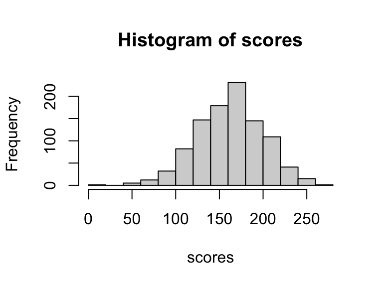

```r
# probability distribution
x <- seq(0,50,10)
px <- c(.1,.2,.1,.1,.4,.1)

# trials and results vector
n_games <- 1000
scores <- c()

for (i in 1:n_games){
  six_rolls <- sample(x,6,replace=T,prob=px)
  scores[i] = sum(six_rolls)
}

hist(scores)
```

Based on this simulation of 1000, we can estimate the probability that I roll at least 200 in a game:

```r
sum(scores>=200)/n_games
```

```
## [1] 0.225
```

**11.** You have two fair 10-sided dice (die A and die B). Don’t ask what they look like, but they are numbered 0-9, not 1-10. Write a `for` loop to record the results of repeating the following game 10000 times: roll each die once and record the value that is 10*A + B in a vector called `results`. (After the loop ends, `results` should have 10000 values.) Then report what the mean and standard deviation of the `results` vector. Also make a histogram of the `results` to see what the shape looks like.

## Part IV: creating functions

A function is a block of code that only runs if it is called. You should consider writing a function whenever you’ve copied and pasted a block of code more than twice (i.e. you now have three copies of the same code). Functions are written with the `function()` key word.

For instance, I might write a function to add rate stats to Lahman Batting data, so that I don’t need to do add them via mutate every time I load it (or consider team totals, etc).

```r
hit_rate_stats <- function(df){
  #this function assumes df has these columns: AB,H,BB,HBP,SF,X2B,X3B,HR.
  df |> mutate(AVG = round(H / AB, 3),
               OBP = round( (H + BB + HBP)/(AB + BB + HBP + SF),3),
               SLG = round( (H + X2B + 2*X3B + 3*HR)/AB,3),
               OPS = OBP + SLG)
  return(df)
}
```

Here’s another function. I call the function `mph_skeeball` because it simulates the total game score for one game (6 rolls) of skee ball using my probability distribution.

```r
mph_skeeball <- function(){
  x <- seq(0,50,10)
  px <- c(.1,.2,.1,.1,.4,.1)
  score <- sum(sample(x,6,replace=T,prob=px))
  return(score)
}
```

Here are scores from 10 simulated mph games:

```r
for (i in 1:10){
  cat("Game",i,"score:",mph_skeeball(),"\n")
}
```

```
## Game 1 score: 120
## Game 2 score: 180
## Game 3 score: 170
## Game 4 score: 200
## Game 5 score: 190
## Game 6 score: 220
## Game 7 score: 170
## Game 8 score: 170
## Game 9 score: 240
## Game 10 score: 130
```

We can generalize the function above to simulate game scores for players of all different levels, on games that allow any number of shots. We do so by **introducing parameters** into the function, which we name `px` (for a player’s probability distribution) and `n` (for the number of rolls). We can also assign **default values** for these parameters in our function definition. I may want default values to be those that I likely use most often. In the case of skee ball I use my personal specs as default values for the parameters.

```r
skeeball_game <- function(px = c(.1,.2,.1,.1,.4,.1), n = 6){
    #px = probability distribution for X
    #n = number of balls
    score <- sum(sample(seq(0,50,10),
                        n,
                        replace=T,
                        prob=px))
    return(score)
}
```

Then, to simulate a game of mine using default parameter values:

```r
my_score <- skeeball_game()
my_score
```

```
## [1] 230
```

And to simulate a game by my brother Dave:

```r
dave_score <- skeeball_game(px = c(.1,.3,.1,.1,.1,.3), n = 6)
dave_score
```

```
## [1] 140
```

Looks like mph dominated that game!

**12**. Write a `for` loop that plays 10000 games between myself (*mph*) and my brother Dave and records each of our scores in each game as well as how many times each of us won. When the dust settles, who won more often? How many times did we tie?

**13.** Write a function called `chuck_a_luck` that takes one input variable `k`, rolls three fair 6-sided dice and returns how many times the value `k` appears on the three dice. For instance, if the input variable is `k = 3`, and you roll 4, 4, and 6, the function should return 0.

**14.** Use your `chuck_a_luck` function to play 10000 times with the number 5, and record in a vector the number of 5s rolled in each attempt. Then use this vector to estimate a probability distribution for $X$, the number of times we roll 5 in a game of chuck-a-luck.